# FINAL PROJECT:

Mamady III DIAKITE 180709719 , Emircan UNAL 190709069

2023-01-16

## 1. Please find your original dataset or datasets; and describe your data in the first

Our DATASET IS about water Quality examınatıon of hemical and biological measurements related to water quality, It has 518 rows and 18 columns, including the concentrations of various elements and compounds, as well as the presence of bacteria and viruses. Each row represents a different sample with measured values for ammonia, arsenic, barium, cadmium, chloramine, chromium, copper, bacteria, viruses, lead, nitrates, mercury, perchlorate ,radium, selenium, silver uranium. The “is_safe” column indicates whether the water is deemed safe based on these measurements. The numbers are displayed in decimal format.

## Loading necessary libraries

```r
library(caret)
library(RANN)
library(randomForest)
library(klaR)
library(ggplot2)
library(corrplot)
library(pROC)
library(ROSE)
library(dplyr)
library(NbClust)
library(kernlab)
library("factoextra")
library(rpart)
library(tidyr)
```

```r
data_frame <- read.csv("waterQuality.csv")
```

## 2.Use “Exploratory data analysis”. Write down your comments.

```r
head(data_frame, 10)
```

```
##    ammonia arsenic barium cadmium chloramine chromium copper bacteria viruses
## 1     9.08    0.04   2.85   0.007       0.35     0.83   0.17     0.20   0.000
## 2    21.16    0.01   3.31   0.002       5.28     0.68   0.66     0.65   0.650
## 3    14.02    0.04   0.58   0.008       4.24     0.53   0.02     0.05   0.003
## 4    11.33    0.04   2.96   0.001       7.23     0.03   1.66     0.71   0.710
## 5    24.33    0.03   0.20   0.006       2.67     0.69   0.57     0.13   0.001
## 6    14.47    0.03   2.88   0.003       0.80     0.43   1.38     0.67   0.670
## 7     5.60    0.01   1.35   0.004       1.28     0.62   1.88     0.13   0.007
## 8    19.87    0.04   0.66   0.001       6.22     0.10   1.86     0.16   0.005
## 9    24.58    0.01   0.71   0.005       3.14     0.77   1.45     0.35   0.002
## 10   16.76    0.02   1.37   0.007       6.40     0.49   0.82     0.83   0.830
##     lead nitrates mercury perchlorate radium selenium silver uranium is_safe
## 1  0.054    16.08   0.007       37.75   6.78     0.08   0.34    0.02     yes
## 2  0.100     2.01   0.003       32.26   3.21     0.08   0.27    0.05     yes
## 3  0.078    14.16   0.006       50.28   7.07     0.07   0.44    0.01      no
## 4  0.016     1.41   0.004        9.12   1.72     0.02   0.45    0.05     yes
## 5  0.117     6.74   0.003       16.90   2.41     0.02   0.06    0.02     yes
## 6  0.135     9.75   0.006       27.17   5.42     0.08   0.19    0.02     yes
## 7  0.021    18.60   0.007       45.34   2.84     0.10   0.24    0.08      no
## 8  0.197    13.65   0.001       53.35   7.24     0.08   0.08    0.07      no
## 9  0.167    14.66   0.004       23.43   4.99     0.08   0.25    0.08     yes
## 10 0.109     4.79   0.010       30.42   0.08     0.03   0.31    0.01     yes
```

```r
str(data_frame)
```

```
## 'data.frame':    518 obs. of  18 variables:
##  $ ammonia    : num  9.08 21.16 14.02 11.33 24.33 ...
##  $ arsenic    : num  0.04 0.01 0.04 0.04 0.03 0.03 0.01 0.04 0.01 0.02 ...
##  $ barium     : num  2.85 3.31 0.58 2.96 0.2 2.88 1.35 0.66 0.71 1.37 ...
##  $ cadmium    : num  0.007 0.002 0.008 0.001 0.006 0.003 0.004 0.001 0.005 0.007 ...
##  $ chloramine : num  0.35 5.28 4.24 7.23 2.67 0.8 1.28 6.22 3.14 6.4 ...
##  $ chromium   : num  0.83 0.68 0.53 0.03 0.69 0.43 0.62 0.1 0.77 0.49 ...
##  $ copper     : num  0.17 0.66 0.02 1.66 0.57 1.38 1.88 1.86 1.45 0.82 ...
##  $ bacteria   : num  0.2 0.65 0.05 0.71 0.13 0.67 0.13 0.16 0.35 0.83 ...
##  $ viruses    : num  0 0.65 0.003 0.71 0.001 0.67 0.007 0.005 0.002 0.83 ...
##  $ lead       : num  0.054 0.1 0.078 0.016 0.117 0.135 0.021 0.197 0.167 0.109 ...
##  $ nitrates   : num  16.08 2.01 14.16 1.41 6.74 ...
##  $ mercury    : num  0.007 0.003 0.006 0.004 0.003 0.006 0.007 0.001 0.004 0.01 ...
##  $ perchlorate: num  37.75 32.26 50.28 9.12 16.9 ...
##  $ radium     : num  6.78 3.21 7.07 1.72 2.41 5.42 2.84 7.24 4.99 0.08 ...
##  $ selenium   : num  0.08 0.08 0.07 0.02 0.02 0.08 0.1 0.08 0.08 0.03 ...
##  $ silver     : num  0.34 0.27 0.44 0.45 0.06 0.19 0.24 0.08 0.25 0.31 ...
##  $ uranium    : num  0.02 0.05 0.01 0.05 0.02 0.02 0.08 0.07 0.08 0.01 ...
##  $ is_safe    : chr  "yes" "yes" "no" "yes" ...
```

```r
# control for any null
sum(is.na(data_frame))
```

```
## [1] 0
```

```r
sapply(data_frame,function(x)sum(is.na(x)))
```

```
##     ammonia     arsenic      barium     cadmium  chloramine    chromium
##           0           0           0           0           0           0
##      copper    bacteria     viruses        lead    nitrates     mercury
##           0           0           0           0           0           0
## perchlorate      radium    selenium      silver     uranium     is_safe
##           0           0           0           0           0           0
```

```r
data_frame$is_safe <- as.factor(data_frame$is_safe)
str(data_frame)
```

```
## 'data.frame':    518 obs. of  18 variables:
##  $ ammonia    : num  9.08 21.16 14.02 11.33 24.33 ...
##  $ arsenic    : num  0.04 0.01 0.04 0.04 0.03 0.03 0.01 0.04 0.01 0.02 ...
##  $ barium     : num  2.85 3.31 0.58 2.96 0.2 2.88 1.35 0.66 0.71 1.37 ...
##  $ cadmium    : num  0.007 0.002 0.008 0.001 0.006 0.003 0.004 0.001 0.005 0.007 ...
##  $ chloramine : num  0.35 5.28 4.24 7.23 2.67 0.8 1.28 6.22 3.14 6.4 ...
##  $ chromium   : num  0.83 0.68 0.53 0.03 0.69 0.43 0.62 0.1 0.77 0.49 ...
##  $ copper     : num  0.17 0.66 0.02 1.66 0.57 1.38 1.88 1.86 1.45 0.82 ...
##  $ bacteria   : num  0.2 0.65 0.05 0.71 0.13 0.67 0.13 0.16 0.35 0.83 ...
##  $ viruses    : num  0 0.65 0.003 0.71 0.001 0.67 0.007 0.005 0.002 0.83 ...
##  $ lead       : num  0.054 0.1 0.078 0.016 0.117 0.135 0.021 0.197 0.167 0.109 ...
##  $ nitrates   : num  16.08 2.01 14.16 1.41 6.74 ...
##  $ mercury    : num  0.007 0.003 0.006 0.004 0.003 0.006 0.007 0.001 0.004 0.01 ...
##  $ perchlorate: num  37.75 32.26 50.28 9.12 16.9 ...
##  $ radium     : num  6.78 3.21 7.07 1.72 2.41 5.42 2.84 7.24 4.99 0.08 ...
##  $ selenium   : num  0.08 0.08 0.07 0.02 0.02 0.08 0.1 0.08 0.08 0.03 ...
##  $ silver     : num  0.34 0.27 0.44 0.45 0.06 0.19 0.24 0.08 0.25 0.31 ...
##  $ uranium    : num  0.02 0.05 0.01 0.05 0.02 0.02 0.08 0.07 0.08 0.01 ...
##  $ is_safe    : Factor w/ 2 levels "no","yes": 2 2 1 2 2 2 1 1 2 2 ...
```

```r
summary(data_frame)
```

```
##     ammonia          arsenic            barium          cadmium
##  Min.   : 0.090   Min.   :0.00100   Min.   :0.0100   Min.   :0.001000
##  1st Qu.: 8.217   1st Qu.:0.01000   1st Qu.:0.9625   1st Qu.:0.002000
##  Median :15.430   Median :0.03000   Median :2.0100   Median :0.004000
##  Mean   :15.263   Mean   :0.02505   Mean   :2.0354   Mean   :0.004442
##  3rd Qu.:22.558   3rd Qu.:0.04000   3rd Qu.:3.0275   3rd Qu.:0.007000
##  Max.   :29.800   Max.   :0.05000   Max.   :4.0000   Max.   :0.009000
##    chloramine       chromium          copper          bacteria
##  Min.   :0.000   Min.   :0.0000   Min.   :0.0100   Min.   :0.0100
##  1st Qu.:2.152   1st Qu.:0.2200   1st Qu.:0.4925   1st Qu.:0.2500
##  Median :4.170   Median :0.4500   Median :0.9900   Median :0.4900
##  Mean   :4.085   Mean   :0.4455   Mean   :0.9865   Mean   :0.4887
##  3rd Qu.:6.090   3rd Qu.:0.6800   3rd Qu.:1.4500   3rd Qu.:0.7300
##  Max.   :7.990   Max.   :0.9000   Max.   :1.9900   Max.   :1.0000
##     viruses            lead            nitrates         mercury
##  Min.   :0.0000   Min.   :0.00300   Min.   : 0.010   Min.   :0.000000
##  1st Qu.:0.0040   1st Qu.:0.05925   1st Qu.: 5.030   1st Qu.:0.003000
##  Median :0.0090   Median :0.10400   Median :10.080   Median :0.005000
##  Mean   :0.3645   Mean   :0.10270   Mean   : 9.731   Mean   :0.005124
##  3rd Qu.:0.7300   3rd Qu.:0.14800   3rd Qu.:14.488   3rd Qu.:0.008000
##  Max.   :1.0000   Max.   :0.20000   Max.   :18.990   Max.   :0.010000
##   perchlorate        radium         selenium           silver
##  Min.   : 0.18   Min.   :0.000   Min.   :0.00000   Min.   :0.0000
##  1st Qu.:16.40   1st Qu.:2.120   1st Qu.:0.02000   1st Qu.:0.1200
##  Median :30.23   Median :4.045   Median :0.05000   Median :0.2400
##  Mean   :29.88   Mean   :4.005   Mean   :0.04909   Mean   :0.2386
##  3rd Qu.:43.48   3rd Qu.:5.952   3rd Qu.:0.07000   3rd Qu.:0.3600
##  Max.   :59.74   Max.   :7.990   Max.   :0.10000   Max.   :0.5000
##     uranium        is_safe
##  Min.   :0.00000   no :260
##  1st Qu.:0.02000   yes:258
##  Median :0.05000
##  Mean   :0.04517
##  3rd Qu.:0.07000
##  Max.   :0.09000
```

### - Write down your comments:

The data has been loaded using the read.csv function. and we display the first 10 rows, checked the structure provided some information about variables types. We also Obtained summary statistics for the dataset using summary(data_frame)..

## 3. Use some “visualization techniques”

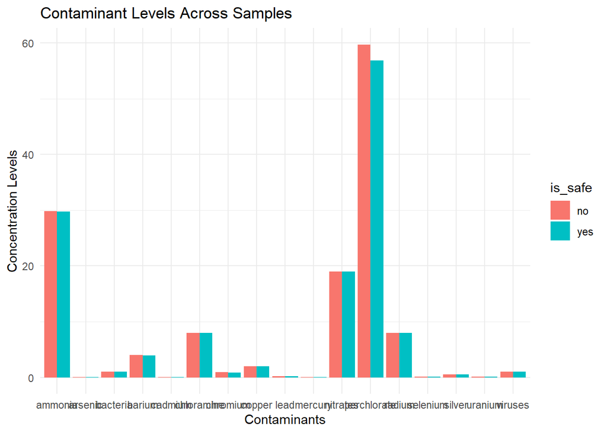

```r
# Bar Chart - Contaminant Levels
data_frame %>%
  gather(key = "Contaminant", value = "Concentration", -is_safe) %>%
  ggplot(aes(x = Contaminant, y = Concentration, fill = is_safe)) +
  geom_bar(stat = "identity", position = "dodge") +
  labs(title = "Contaminant Levels Across Samples",
       x = "Contaminants",
       y = "Concentration Levels") +
  theme_minimal()
```

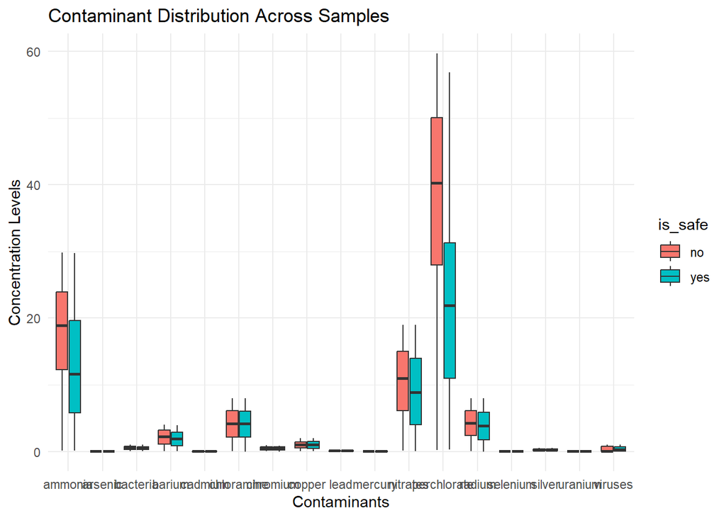

```r
# Box Plot - Contaminant Distribution
data_frame %>%
  gather(key = "Contaminant", value = "Concentration", -is_safe) %>%
  ggplot(aes(x = Contaminant, y = Concentration, fill = is_safe)) +
  geom_boxplot() +
  labs(title = "Contaminant Distribution Across Samples",
       x = "Contaminants",
       y = "Concentration Levels") +
  theme_minimal()
```

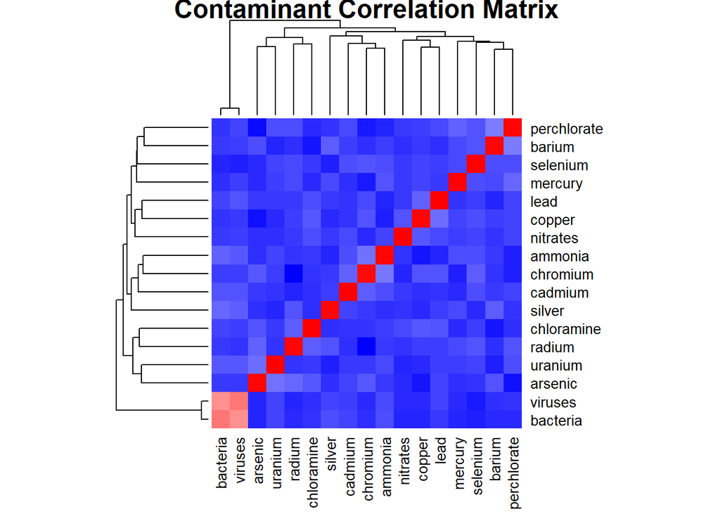

```r
# Heatmap - Contaminant Correlation
correlation_matrix <- cor(data_frame[, -ncol(data_frame)])
heatmap(correlation_matrix,
        col = colorRampPalette(c("blue", "white", "red"))(100),
        main = "Contaminant Correlation Matrix")
```

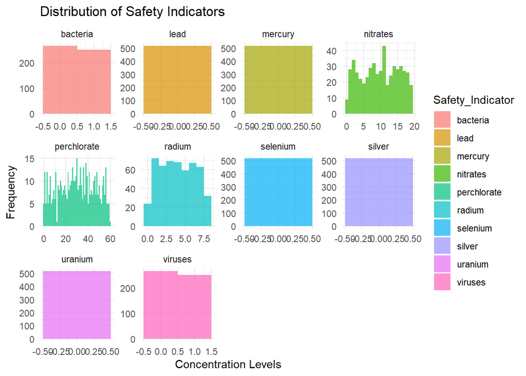

```r
# Histogram - Distribution of Safety Indicators
data_frame %>%
  gather(key = "Safety_Indicator", value = "Concentration", bacteria:uranium) %>%
  ggplot(aes(x = Concentration, fill = Safety_Indicator)) +
  geom_histogram(binwidth = 1, position = "stack", alpha = 0.7) +
  facet_wrap(~Safety_Indicator, scales = "free") +
  labs(title = "Distribution of Safety Indicators",
       x = "Concentration Levels",
       y = "Frequency") +
  theme_minimal()
```

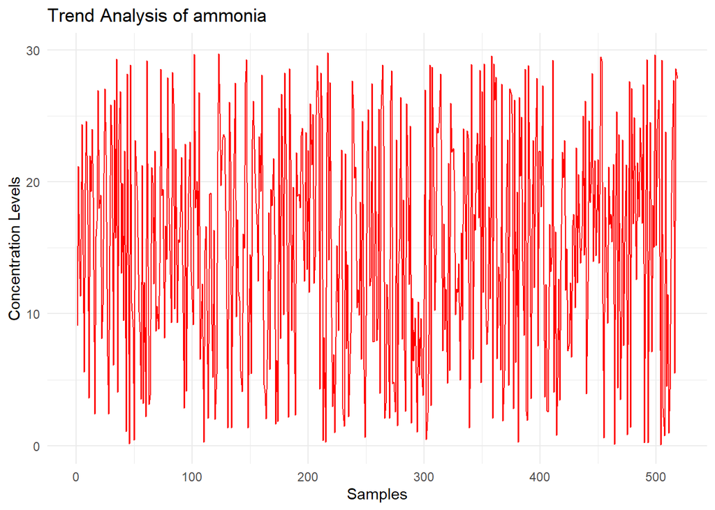

```r
# Line Chart - Trend Analysis (Choose a specific contaminant)
selected_contaminant <- "ammonia"
data_frame %>%
  ggplot(aes(x = seq_along(1:nrow(data_frame)), y = get(selected_contaminant))) +
  geom_line(color = "red") +  # Set the line color to red
  labs(title = paste("Trend Analysis of", selected_contaminant),
       x = "Samples",
       y = "Concentration Levels") +
  theme_minimal()
```

### Talk about your data further.

1- The box plot provides a visual summary of the distribution of contaminant concentrations.

3- The heatmap visualizes the correlation matrix of contaminants.

4- The histograms displays the distribution of concentration levels.

5- The line chart shows the analysis for a specific contaminant (ammonia).

## 4.Check data for multicollinearity,

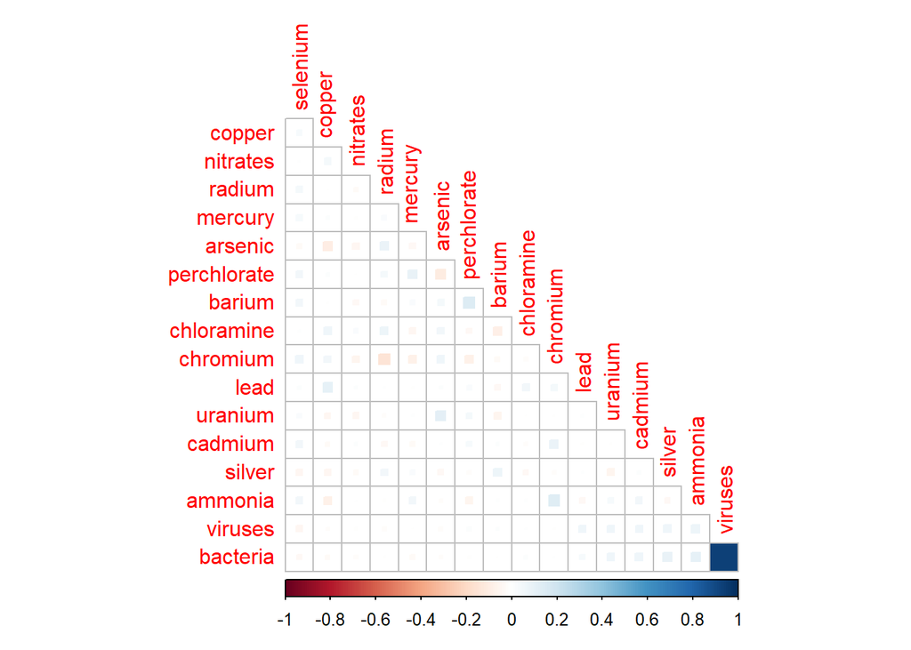

```r
numeric_data <- data_frame[, sapply(data_frame, is.numeric)]
scaled_data <- scale(numeric_data)
correlation_matrix <- cor(scaled_data)
corrplot(correlation_matrix, method = 'square', order = 'FPC', type = 'lower', diag = FALSE)
```

### Make your comments.

First we Scaled data to have a mean of 0 and a standard deviation of 1. for comparison or present scales. than we compute the correlation matrix to observe how each variable correlates with others. A high correlation coefficient (close to 1 or -1) between two variables indicates multicollinearity, meaning those variables are closely related and might be giving similar information.

## 5. (7p) Apply PCA:

### a Use appropriate functions and arguments

```r
pca_result <- prcomp(scaled_data)
summary(pca_result)
```

```
## Importance of components:
##                           PC1     PC2     PC3     PC4     PC5     PC6     PC7
## Standard deviation     1.4098 1.15479 1.12323 1.11258 1.08237 1.03996 1.03086
## Proportion of Variance 0.1169 0.07844 0.07421 0.07281 0.06891 0.06362 0.06251
## Cumulative Proportion  0.1169 0.19536 0.26957 0.34239 0.41130 0.47492 0.53743
##                            PC8    PC9    PC10   PC11    PC12    PC13    PC14
## Standard deviation     1.00530 0.9748 0.97105 0.9501 0.93713 0.93171 0.91512
## Proportion of Variance 0.05945 0.0559 0.05547 0.0531 0.05166 0.05106 0.04926
## Cumulative Proportion  0.59688 0.6528 0.70825 0.7613 0.81301 0.86407 0.91333
##                           PC15    PC16    PC17
## Standard deviation     0.88073 0.79436 0.25818
## Proportion of Variance 0.04563 0.03712 0.00392
## Cumulative Proportion  0.95896 0.99608 1.00000
```